# Relatório Caso Prático 23

Grupo 23

Daniel Alexandre da Silva Fonseca | N° 125158

Guilherme Gonçalves Pires | N° 131658

João Afonso Carreira Filipe | N° 130665

Nuno Costa | N° 130661

Ricardo Ferreira | N° 125123

2025-03-30

# Introdução

A saúde psicológica e o bem-estar das crianças e adolescentes são fatores determinantes para o seu desenvolvimento pessoal e sucesso escolar. O impacto da pandemia da *Covid-19* acarretou desafios significativos para o mundo, no entanto este grupo etário - caraterizado por estarem em processo de puberdade foi um dos mais afetados psicologicamente, exigindo uma análise aprofundada sobre as suas condições emocionais e sociais. Neste contexto, o estudo *Saúde Psicológica e Bem-estar*, promovido pelo Ministério da Educação em 2022, visa compreender o panorama da saúde mental dos estudantes portugueses, desde o pré-escolar até ao 12.º ano, considerando diferentes regiões do país.

O presente relatório é baseado numa análise exploratória de dados, tendo como objetivo examinar uma amostra das respostas ao questionário aplicado, procurando identificar padrões e tendências relevantes. Foram analisadas respostas dos alunos a vários sintomas depressivos, a idade, o ciclo escolar e as horas de sono. Através da aplicação de algumas técnicas estatísticas e visualização de dados, pretende-se obter uma visão mais clara sobre o estado emocional dos alunos e analisar possíveis correlações entre as variáveis em estudo.

Para que tal seja possível, de forma grupal, decidimos segmentar o relatório em diversos pontos-chave, de forma a encontrar possíveis correlações, nomeadamente:

**1.** A análise inicial foca-se no **número de horas de sono** dos alunos, dado que a qualidade e a quantidade de sono têm um impacto direto no bem-estar emocional e psicológico.  
**2.** Avaliar a **influência do género** nas respostas relacionadas com a saúde psicológica e bem-estar, com foco nas diferenças nos sintomas de depressão entre rapazes e raparigas.  
**3.** Examinar se existe uma **correlação entre as horas de sono e os sintomas de depressão**.  
**4.** **Faixa etária e sintomas depressivos**, com o intuito de identificar se existem grupos etários mais vulneráveis aos sintomas depressivos após a pandemia.  
**5.** Por fim, será que é possível observar uma **relação** entre a **preocupação excessiva** (“Eu preocupo-me com muitas coisas”) e **sintomas depressivos** para entender se há uma tendência a preocupar-se mais está associada ao aumento de sintomas depressivos.

# O inquérito e a amostra

A estrutura do inquérito incluía uma série de questões relacionadas com sintomas depressivos:

**1.** Não consegui sentir nenhum sentimento positivo.  
**2.** Tive muita dificuldade em ter iniciativa para fazer coisas.  
**3.** Senti que não tinha nada a esperar do futuro.  
**4.** Senti-me triste e deprimido.  
**5.** Não fui capaz de ter entusiasmo para nada.  
**6.** Senti que não tinha muito valor como pessoa.  
**7.** Senti que não vale a pena viver.  
**8.** Eu preocupo-me com muitas coisas.

As respostas dos alunos foram recolhidas numa escala de **0** a **3**, onde 0 significava “Não se aplicou a mim” e 3 “Aplicou-se a mim na maior parte do tempo”. Além das questões sobre saúde emocional, foi pedido aos alunos que partilhassem também, em geral, quantas horas dormem por noite.

A amostra deste estudo é composta por **618** alunos, da região **Norte** de Portugal. Apresenta uma distribuição de género bastante proporcional, sendo **46.9%** masculino e **48.9%** feminino. O restante da amostra, identifica-se como “outro” **0.8%** e **3.4%** não partilhou este dado. Os alunos questionados encontram-se no 3º e 4º ciclo do ensino básico, compreendidos numa faixa etária entre os **11** e **20** anos. Em média, a idade dos participantes era **14.3** anos.

| Genero | n | Percentagem |
| --- | --- | --- |
| Masculino | 290 | 46.9 |
| Feminino | 302 | 48.9 |
| Outro | 5 | 0.8 |
| Não respondeu | 21 | 3.4 |

**Figura 1:** Distribuição dos géneros entre os alunos questionados

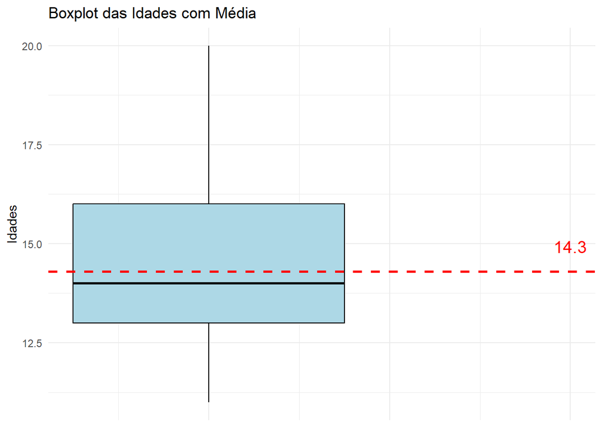

**Figura 2:** Distribuição das idades entre os alunos questionados

# Horas de sono dos alunos

Inicialmente, deparados com esta base de dados, a intuição foi analisar as horas de sono, dado que (em certa parte, estereotipicamente) os sintomas depressivos estão relacionados com as horas de sono. No caso prático em questão, devido ao panorama *Covid-19*, ao estarem confinados em casa, seria de esperar que os alunos dormissem mais horas que o habitual, devido à transição para uma rotina mais monótona e com menos atividade física presente nas suas vidas. O gráfico a seguir ilustra a distribuição das horas de sono dos alunos, observando-se uma distribuição normal, mas enviesada à esquerda, indicando que a maioria dos alunos dorme acima do número de horas recomendado (>7) com a maioria dormindo 8 horas por noite.

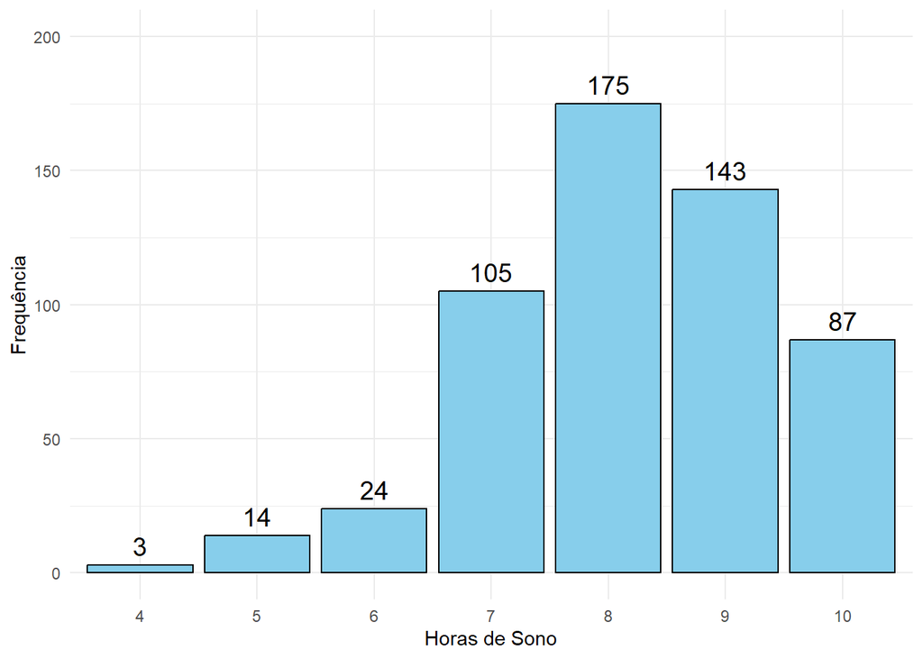

**Figura 3:** Distribuição horas de sono dos alunos

Este resultado sugere que, em média, os alunos dormem o número de horas adequado às recomendações para a sua faixa etária, o que defende a ideia de que a rotina na pandemia pode ter levado a um aumento no número de horas dormidas. No entanto, posteriormente iremos analisar se este parâmetro implica sintomas mais ou menos depressivos ou vice versa.

# Relação entre género e sintomas depressivos

O gráfico seguinte apresenta a média das respostas às questões sobre sintomas depressivos, segmentadas por género.

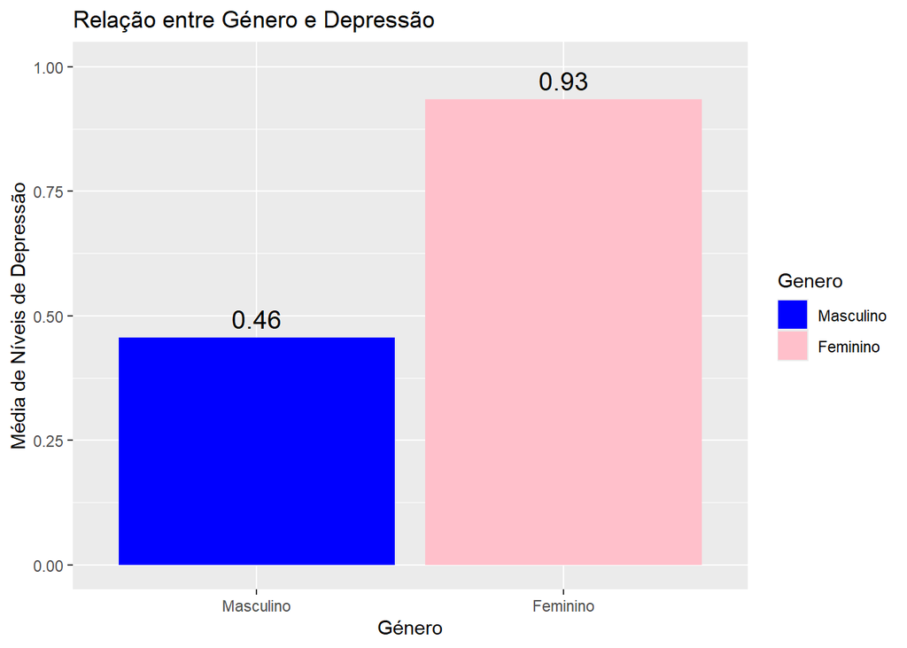

**Figura 4:** Relação entre média de respostas a sintomas depressivos e género

É possível observar que o género feminino apresenta mais sintomas depressivos, com uma média de **0.93** por resposta, numa escala de 0 a 3, enquanto o género masculino apresenta uma média por resposta de **0.46**. Apesar de não ser um valor elevado em termos absolutos, a diferença relativa sugere que o género feminino é mais propenso a sentir sintomas depressivos.

No entanto, essa diferença pode refletir um maior impacto psicológico das condições de confinamento e da pandemia sobre as raparigas, possivelmente devido a fatores socioculturais que envolvem maiores expectativas emocionais sobre as mulheres, bem como a maior vulnerabilidade social e emocional observada neste grupo.

# Horas de sono e depressão

# Será que existe alguma faixa etária com maiores níveis de depressão?

A partir de uma certa faixa etária, aliado à puberdade vivenciada por todos os adolescentes, com níveis acrescidos de responsabilidades, assim como possível pressão em entrar no mundo universitário e terminar um ciclo escolar, seria expetável que inquiridos mais velhos apresentassem maiores níveis de depressão. O gráfico seguinte ilustra a média dos níveis de depressão por faixa etária.

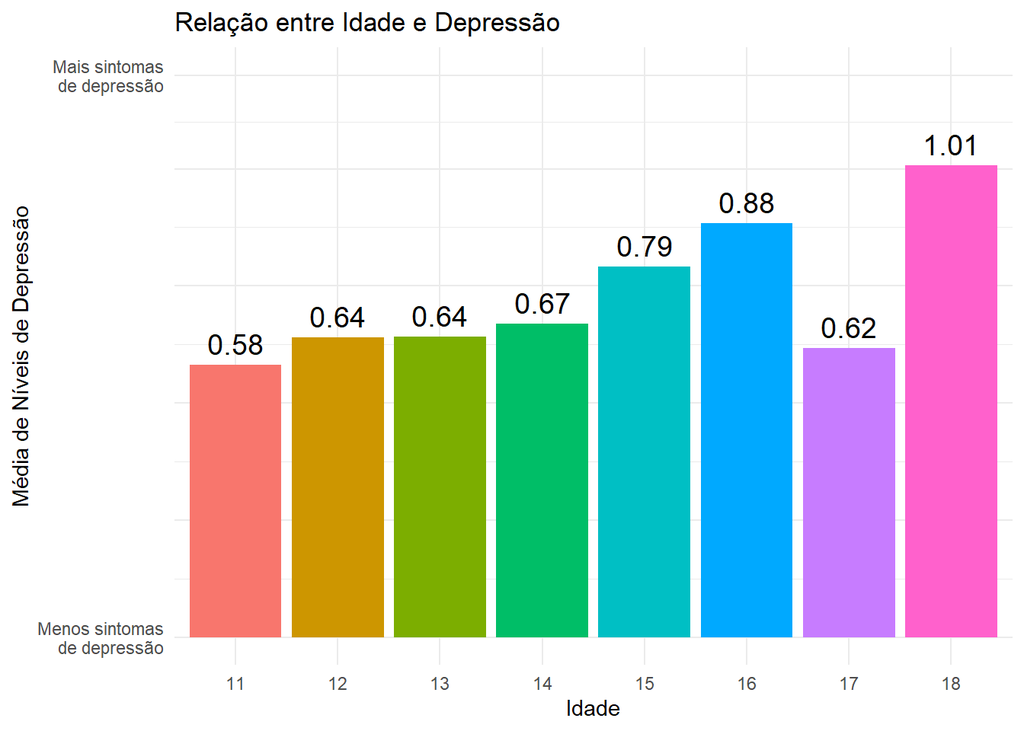

**Figura 5:** Relação entre idades e depressão

Desta forma podemos observar que, pós pandemia, como esperado, há uma tendência crescente de sintomas depressivos à medida que a idade aumenta. Apesar desta tese, a faixa etária de 17 anos apresentou resultados fora da tendência, mostrando menores níveis de depressão.

# Relação entre a a preocupação excessiva e sintomas depressivos

Além disso, é possível que a preocupação excessiva esteja mais ligada ao stresse ou a padrões individuais de personalidade do que à depressão propriamente dita.

# Conclusão

A análise dos dados coletados permitiu uma visão abrangente sobre os fatores que afetam a saúde psicológica dos alunos da região Norte de Portugal, com destaque para a relação entre género, idade e sintomas depressivos.

Embora alguns resultados tenham sido consistentes com as expectativas, a maior prevalência de sintomas depressivos entre as raparigas e a tendência crescente de depressão com a idade são questões que merecem maior atenção nas estratégias de apoio psicológico. Outras análises, como a relação entre horas de sono e depressão, não apresentaram resultados conclusivos. A pesquisa sublinha a necessidade de um acompanhamento mais personalizado para os alunos, de forma a atender às suas necessidades emocionais específicas, especialmente em tempos de crise, como foi o caso da pandemia.